# Project 2: NOAA Storm Database Analysis

Danielle D

April 16, 2016

# Synopsis

This project involves exploring the U.S. National Oceanic and Atmospheric Administration’s (NOAA) storm database. The events in the database start in the year 1950 and end in November 2011.

This report looks at two questions:

1. Across the United States, which types of events are most harmful with respect to population health?
2. Across the United States, which types of events have the greatest economic consequences?

Analysis shows that tornados caused the most fatalities (5633) and injuries (91346) in the US and that floods have had the greatest economical impact in the US (around 150 billion USD).

# Data Processing

### Download the files if it does not exist in the current wd

```r
    if (!file.exists("repdata-data-StormData.csv.bz2")) {
    download.file("https://d396qusza40orc.cloudfront.net/repdata%2Fdata%2FStormData.csv.bz2",
    "repdata-data-StormData.csv.bz2")
}
```

### Read the file

```r
    weather <- read.csv(bzfile("repdata-data-StormData.csv.bz2"))
```

### Get a look at weather to identify the desired event types

```r
    str(weather)
```

```
## 'data.frame':    902297 obs. of  37 variables:
##  $ STATE__   : num  1 1 1 1 1 1 1 1 1 1 ...
##  $ BGN_DATE  : Factor w/ 16335 levels "1/1/1966 0:00:00",..: 6523 6523 4242 11116 2224 2224 2260 383 3980 3980 ...
##  $ BGN_TIME  : Factor w/ 3608 levels "00:00:00 AM",..: 272 287 2705 1683 2584 3186 242 1683 3186 3186 ...
##  $ TIME_ZONE : Factor w/ 22 levels "ADT","AKS","AST",..: 7 7 7 7 7 7 7 7 7 7 ...
##  $ COUNTY    : num  97 3 57 89 43 77 9 123 125 57 ...
##  $ COUNTYNAME: Factor w/ 29601 levels "","5NM E OF MACKINAC BRIDGE TO PRESQUE ISLE LT MI",..: 13513 1873 4598 10592 4372 10094 1973 23873 24418 4598 ...
##  $ STATE     : Factor w/ 72 levels "AK","AL","AM",..: 2 2 2 2 2 2 2 2 2 2 ...
##  $ EVTYPE    : Factor w/ 985 levels "   HIGH SURF ADVISORY",..: 834 834 834 834 834 834 834 834 834 834 ...
##  $ BGN_RANGE : num  0 0 0 0 0 0 0 0 0 0 ...
##  $ BGN_AZI   : Factor w/ 35 levels "","  N"," NW",..: 1 1 1 1 1 1 1 1 1 1 ...
##  $ BGN_LOCATI: Factor w/ 54429 levels "","- 1 N Albion",..: 1 1 1 1 1 1 1 1 1 1 ...
##  $ END_DATE  : Factor w/ 6663 levels "","1/1/1993 0:00:00",..: 1 1 1 1 1 1 1 1 1 1 ...
##  $ END_TIME  : Factor w/ 3647 levels ""," 0900CST",..: 1 1 1 1 1 1 1 1 1 1 ...
##  $ COUNTY_END: num  0 0 0 0 0 0 0 0 0 0 ...
```

[output cut: 23 more lines]

### Pull out only the columns that are useful for the purpose of this report and can assist in answering our two questions below.

```r
    weatherSubset <- weather[, c("BGN_DATE", "EVTYPE", "FATALITIES", "INJURIES", "PROPDMG",          "PROPDMGEXP", "CROPDMG", "CROPDMGEXP")]
```

### Check out our subsetting of data

```r
    head(weatherSubset)
```

```
##             BGN_DATE  EVTYPE FATALITIES INJURIES PROPDMG PROPDMGEXP
## 1  4/18/1950 0:00:00 TORNADO          0       15    25.0          K
## 2  4/18/1950 0:00:00 TORNADO          0        0     2.5          K
## 3  2/20/1951 0:00:00 TORNADO          0        2    25.0          K
## 4   6/8/1951 0:00:00 TORNADO          0        2     2.5          K
## 5 11/15/1951 0:00:00 TORNADO          0        2     2.5          K
## 6 11/15/1951 0:00:00 TORNADO          0        6     2.5          K
##   CROPDMG CROPDMGEXP
## 1       0
## 2       0
## 3       0
## 4       0
## 5       0
## 6       0
```

# Results

### Question 1: Across the United States, which type of events are most harmful with respect to populational health?

First let’s define what will go into the definition of “health”. Of the event types provided we will include the following in our definition of “health”: Fatalities and Injuries

```r
    healthScore <- subset(weatherSubset, FATALITIES!=0 | INJURIES!=0)
    summary(healthScore)
```

```
##                BGN_DATE                   EVTYPE       FATALITIES
##  4/3/1974 0:00:00  :  134   TORNADO          :7928   Min.   :  0.0000
##  4/27/2011 0:00:00 :  120   LIGHTNING        :3305   1st Qu.:  0.0000
##  4/11/1965 0:00:00 :   54   TSTM WIND        :2930   Median :  0.0000
##  5/31/1998 0:00:00 :   44   FLASH FLOOD      : 931   Mean   :  0.6906
##  3/1/1997 0:00:00  :   41   THUNDERSTORM WIND: 682   3rd Qu.:  1.0000
##  11/22/1992 0:00:00:   39   EXCESSIVE HEAT   : 678   Max.   :583.0000
##  (Other)           :21497   (Other)          :5475
##     INJURIES           PROPDMG          PROPDMGEXP       CROPDMG
##  Min.   :   0.000   Min.   :   0.00   K      :11155   Min.   :  0.0
##  1st Qu.:   1.000   1st Qu.:   0.00          : 7248   1st Qu.:  0.0
##  Median :   1.000   Median :   2.50   M      : 3497   Median :  0.0
##  Mean   :   6.408   Mean   :  61.92   B      :   19   Mean   :  3.2
##  3rd Qu.:   3.000   3rd Qu.:  30.00   0      :    5   3rd Qu.:  0.0
##  Max.   :1700.000   Max.   :3200.00   -      :    1   Max.   :900.0
##                                       (Other):    4
##    CROPDMGEXP
##         :17490
##  K      : 4253
##  M      :  184
##  0      :    1
##  B      :    1
##  ?      :    0
##  (Other):    0
```

### Now we’ll find the total fatalties and injuries by type of weather event

```r
      weatherFatal <- aggregate(FATALITIES ~ EVTYPE, data=weatherSubset, FUN=sum)
      weatherInjury <- aggregate(INJURIES ~ EVTYPE, data=weatherSubset, FUN=sum)
      weatherHealth <- aggregate(cbind(INJURIES, FATALITIES) ~ EVTYPE, data = weatherSubset, FUN = sum)
```

### That’s a lot of event types. Let’s pair down event types to only the top 10.

```r
library(dplyr)
weatherFatal1 <- weatherFatal %>%
  filter(FATALITIES > 0 ) %>%
  group_by(EVTYPE) %>%
  summarise (FATALITIES = sum(FATALITIES, na.rm = TRUE)) %>%
  arrange(desc(FATALITIES)) %>%
  head(10)
```

```r
library(dplyr)
weatherInjury1 <- weatherInjury %>%
  filter(INJURIES > 0 ) %>%
  group_by(EVTYPE) %>%
  summarise (INJURIES = sum(INJURIES, na.rm = TRUE)) %>%
  arrange(desc(INJURIES)) %>%
  head(10)
```

### Tornados cause the most fatalties when calculating using the provided NOAA data.

```r
library(knitr,quietly=T)
  kable(head(arrange(weatherFatal1,desc(FATALITIES)), n=10),format="markdown")
```

| EVTYPE | FATALITIES |
| --- | --- |
| TORNADO | 5633 |
| EXCESSIVE HEAT | 1903 |
| FLASH FLOOD | 978 |
| HEAT | 937 |
| LIGHTNING | 816 |
| TSTM WIND | 504 |
| FLOOD | 470 |
| RIP CURRENT | 368 |
| HIGH WIND | 248 |
| AVALANCHE | 224 |

### Tornados still top the list for injuries but we see a few unique entries versus the fatalities list.

```r
library(knitr,quietly=T)
kable(head(arrange(weatherInjury1,desc(INJURIES)), n=10),format="markdown")
```

| EVTYPE | INJURIES |
| --- | --- |
| TORNADO | 91346 |
| TSTM WIND | 6957 |
| FLOOD | 6789 |
| EXCESSIVE HEAT | 6525 |
| LIGHTNING | 5230 |
| HEAT | 2100 |
| ICE STORM | 1975 |
| FLASH FLOOD | 1777 |
| THUNDERSTORM WIND | 1488 |
| HAIL | 1361 |

# Fatalities by Top 10 Weather Events

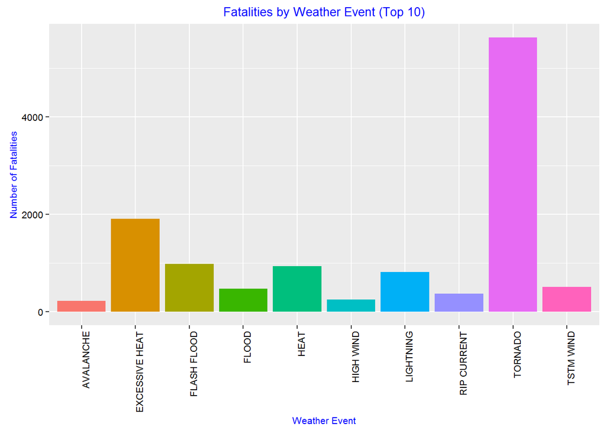

```r
   library(ggplot2)
ggplot(weatherFatal1, aes(x = EVTYPE, y = FATALITIES, fill = EVTYPE, scale_fill_brewer(palette = "Set2"))) +
geom_bar(stat = "identity") +
  labs(title = "Fatalities by Weather Event (Top 10)", x = "Weather Event", y = "Number of Fatalities") +
  theme_gray() +

  theme(axis.text=element_text(color="black",size=8), legend.position = "none") +
  theme(axis.text.x=element_text(angle = 90, hjust = 1)) +
  theme(axis.title.x=element_text(color="blue", size=8), ## x title blue
  axis.title.y=element_text(color="blue", size=8), ## y title blue
  plot.title=element_text(color="blue",size=10)) ##set title blue and 12pt
```

```r
  #ggsave(file = 'health.png')
```

# Question 2: Across the United States, which types of events have the greatest economic consequences?

### In order to address this issue we need to take a look at our data to see what gives us an indication of economic consequences. We have four columns that will give us insight into the economic impact of different event types.

1. PROPDMG - Contains the amount rounded to three signifigant digits
2. PROPDMGEXP - Alpha character to signify the magnitude (B = Billion, K = Thousands, M = Million)
3. CROPDMG - Contains the amount rounded to three signifigant digits
4. CROPDMGEXP - Alpha character to signify the magnitude (B = Billion, K = Thousands, M = Million)

[REFERENCE: Propery and Crop Damage Calculations from NOAA](https://d396qusza40orc.cloudfront.net/repdata%2Fpeer2_doc%2Fpd01016005curr.pdf)

### Let’s take a look at the subset of weather data to see whta’s lurking in the PROPDMGEXP and CROPDMGEXP columns.

```r
levels(weatherSubset$PROPDMGEXP)
```

```
##  [1] ""  "-" "?" "+" "0" "1" "2" "3" "4" "5" "6" "7" "8" "B" "h" "H" "K"
## [18] "m" "M"
```

```r
levels(weatherSubset$CROPDMGEXP)
```

```
## [1] ""  "?" "0" "2" "B" "k" "K" "m" "M"
```

### We definitly have some values that need to be cleaned up in the PROPDMGEXP and CROPDMGEXP areas. Below we will clean up those values before we proceed with the damage calculations. Starting with CROPDMGEXP.

```r
weatherSubset$CROPEXP[weatherSubset$CROPDMGEXP == ""] <- 1
weatherSubset$CROPEXP[weatherSubset$CROPDMGEXP == "?"] <- 1
weatherSubset$CROPEXP[weatherSubset$CROPDMGEXP == "0"] <- 1
weatherSubset$CROPEXP[weatherSubset$CROPDMGEXP == "2"] <- 1
weatherSubset$CROPEXP[weatherSubset$CROPDMGEXP == "k"] <- 1000
weatherSubset$CROPEXP[weatherSubset$CROPDMGEXP == "K"] <- 1000
weatherSubset$CROPEXP[weatherSubset$CROPDMGEXP == "m"] <- 1e+06
weatherSubset$CROPEXP[weatherSubset$CROPDMGEXP == "M"] <- 1e+06
weatherSubset$CROPEXP[weatherSubset$CROPDMGEXP == "B"] <- 1e+09
```

### Now a little cut and past magic and let’s do the same thing with PROPDMGEXP. Here all values that were invalid according to the NOAA documentation were coverted to ‘1’.

```r
weatherSubset$PROPEXP[weatherSubset$PROPDMGEXP == ""] <- 1
weatherSubset$PROPEXP[weatherSubset$PROPDMGEXP == "+"] <- 1
weatherSubset$PROPEXP[weatherSubset$PROPDMGEXP == "-"] <- 1
weatherSubset$PROPEXP[weatherSubset$PROPDMGEXP == "?"] <- 1
weatherSubset$PROPEXP[weatherSubset$PROPDMGEXP == "0"] <- 1
weatherSubset$PROPEXP[weatherSubset$PROPDMGEXP == "1"] <- 1
weatherSubset$PROPEXP[weatherSubset$PROPDMGEXP == "2"] <- 1
weatherSubset$PROPEXP[weatherSubset$PROPDMGEXP == "h"] <- 1
weatherSubset$PROPEXP[weatherSubset$PROPDMGEXP == "H"] <- 1
weatherSubset$PROPEXP[weatherSubset$PROPDMGEXP == "3"] <- 1
weatherSubset$PROPEXP[weatherSubset$PROPDMGEXP == "K"] <- 1000
weatherSubset$PROPEXP[weatherSubset$PROPDMGEXP == "4"] <- 1
weatherSubset$PROPEXP[weatherSubset$PROPDMGEXP == "5"] <- 1
weatherSubset$PROPEXP[weatherSubset$PROPDMGEXP == "6"] <- 1
weatherSubset$PROPEXP[weatherSubset$PROPDMGEXP == "m"] <- 1e+06
weatherSubset$PROPEXP[weatherSubset$PROPDMGEXP == "M"] <- 1e+06
weatherSubset$PROPEXP[weatherSubset$PROPDMGEXP == "7"] <- 1
weatherSubset$PROPEXP[weatherSubset$PROPDMGEXP == "8"] <- 1
weatherSubset$PROPEXP[weatherSubset$PROPDMGEXP == "B"] <- 1e+09
```

### Now let’s total up the damage for each instance and create a new column for those values.

```r
weatherSubset$PropVal <- weatherSubset$PROPDMG * weatherSubset$PROPEXP

weatherSubset$CropVal <- weatherSubset$CROPDMG * weatherSubset$CROPEXP
```

### Now we are going to find the Top 10 in each area of economic impact.

```r
weatherProp <- weatherSubset %>%
  filter(PropVal > 0 ) %>%
  group_by(EVTYPE) %>%
  summarise (PropVal = sum(PropVal, na.rm = TRUE)) %>%
  arrange(desc(PropVal)) %>%
  head(10)
```

```r
weatherCrop <- weatherSubset %>%
  filter(CropVal > 0 ) %>%
  group_by(EVTYPE) %>%
  summarise (CropVal = sum(CropVal, na.rm = TRUE)) %>%
  arrange(desc(CropVal)) %>%
  head(10)
```

### Droughts and floods have the largest economic impact on crops. Not surprising. Plants do need water to survive - not too much and not too little.

```r
library(knitr,quietly=T)
  kable(head(arrange(weatherCrop,desc(CropVal)), n=10),format="markdown")
```

| EVTYPE | CropVal |
| --- | --- |
| DROUGHT | 13972566000 |
| FLOOD | 5661968450 |
| RIVER FLOOD | 5029459000 |
| ICE STORM | 5022113500 |
| HAIL | 3025954473 |
| HURRICANE | 2741910000 |
| HURRICANE/TYPHOON | 2607872800 |
| FLASH FLOOD | 1421317100 |
| EXTREME COLD | 1292973000 |
| FROST/FREEZE | 1094086000 |

### In terms of property damage floods top the list followed by hurricanes and tornados.

```r
library(knitr,quietly=T)
  kable(head(arrange(weatherProp,desc(PropVal)), n=10),format="markdown")
```

| EVTYPE | PropVal |
| --- | --- |
| FLOOD | 144657709807 |
| HURRICANE/TYPHOON | 69305840000 |
| TORNADO | 56937160779 |
| STORM SURGE | 43323536000 |
| FLASH FLOOD | 16140812067 |
| HAIL | 15732267048 |
| HURRICANE | 11868319010 |
| TROPICAL STORM | 7703890550 |
| WINTER STORM | 6688497251 |
| HIGH WIND | 5270046295 |

### We’ll add the values for our total property damage and total crop damage together and then we will graph that final value to determine which events make up our Top 10 greatest economic losses.

```r
weatherSubset$TotalLoss <- weatherSubset$PropVal + weatherSubset$CropVal
```

```r
weatherTotalLoss <- weatherSubset %>%
  filter(TotalLoss > 1 ) %>%
  group_by(EVTYPE) %>%
  summarise (TotalLoss = sum(TotalLoss, na.rm = TRUE)) %>%
  arrange(desc(TotalLoss)) %>%
  head(10)
```

```r
library(knitr,quietly=T)
  kable(head(arrange(weatherTotalLoss,desc(TotalLoss)), n=10),format="markdown")
```

| EVTYPE | TotalLoss |
| --- | --- |
| FLOOD | 150319678257 |
| HURRICANE/TYPHOON | 71913712800 |
| TORNADO | 57352114048 |
| STORM SURGE | 43323541000 |
| HAIL | 18758221517 |
| FLASH FLOOD | 17562129166 |
| DROUGHT | 15018672000 |
| HURRICANE | 14610229010 |
| RIVER FLOOD | 10148404500 |
| ICE STORM | 8967041360 |

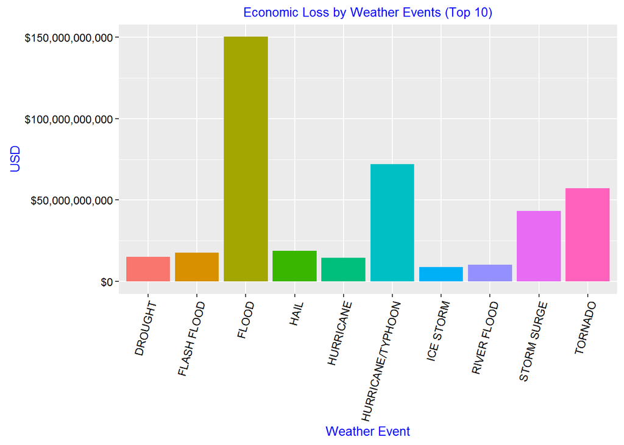

```r
library(ggplot2)
ggplot(weatherTotalLoss, aes(x = EVTYPE, y = TotalLoss, fill = EVTYPE, scale_fill_brewer(palette = "Set2"))) +
  scale_y_continuous(labels = scales::dollar) +
geom_bar(stat = "identity") +
  labs(title = "Economic Loss by Weather Events (Top 10)", x = "Weather Event", y = "USD") +
  theme_gray() +

  theme(axis.text=element_text(color="black",size=9), legend.position = "none") +
  theme(axis.text.x=element_text(angle = 75, hjust = 1)) +
  theme(axis.title.x=element_text(color="blue", size=10), ## x title blue
  axis.title.y=element_text(color="blue", size=10), ## y title blue
  plot.title=element_text(color="blue",size=10)) ##set title blue and 12pt
```

```r
  ggsave(file = 'economic.png', width = 18, height = 18, units = "cm")
```

# Conclusion

### Tornados top the list in terms of health impact according to our data. Floods cause the greatest econonmic damage.